# hedging_test

## Import

```python
# !pip install yfinance
# !pip install quandl
# !pip install pmdarima
```

```python
import csv
import numpy as np
import pandas as pd
import matplotlib.pyplot as plt
import seaborn as sns
import scipy as sc
from scipy.stats import norm
import yfinance as yf
# import quandl
import warnings
# import plotly.express as px
# import plotly.graph_objects as go

warnings.filterwarnings('ignore')

# import pmdarima as pmd
from itertools import cycle
from datetime import datetime, date
# from io import StringIO
# from scipy.special import betainc

from pandas.plotting import register_matplotlib_converters
register_matplotlib_converters()

pd.options.mode.chained_assignment = None
pd.set_option('display.max_rows', 500)
pd.set_option('display.max_columns', 500)
pd.set_option('display.width', 1000)

sns.set_style('whitegrid')
plt.rcParams.update({'axes.labelsize': 'x-large', 'figure.figsize': (16, 9)})
```

## Dane

### Ładowanie danych

Małe oszustwo, ale nie miałem czasu poszukać odpowiednich cen kawy - jako kurs spotowy przyjmiemy 3M futures, w rzeczywistości te ceny są bardzo zbliżone.

Dodatkowo, w ramach rozgrzewki, sprawdźmy kurs firmy Starbucks

```python
symbols = ['KC=F', 'SBUX']
print(symbols)
```

```
['KC=F', 'SBUX']
```

```python
from_date = pd.Timestamp('2020.01.01')
to_date = datetime.today().date()

yf_df = yf.download(symbols, start=from_date, end=to_date)
# clean stooq data
yf_df.columns.set_names(['Attributes', 'Symbols'], level=[0, 1], inplace=True)
unstacked = yf_df.unstack().to_frame().reset_index()
```

```
[*********************100%***********************]  2 of 2 completed
```

```python
final = unstacked.pivot(index=['Symbols', 'Date'], columns=['Attributes'])
final.columns = final.columns.droplevel()
final.reset_index(inplace=True)
final.rename_axis(None, axis=1, inplace=True)
final.columns = map(str.lower, final.columns)
final.rename(columns={'symbols': 'symbol'}, inplace=True)
final = final.reindex(sorted(final.columns), axis=1)
final.sort_values(by=['symbol', 'date', ], inplace=True, ignore_index=True)
final
```

|  | adj close | close | date | high | low | open | symbol | volume |
| --- | --- | --- | --- | --- | --- | --- | --- | --- |
| 0 | 127.099998 | 127.099998 | 2020-01-02 | 130.949997 | 126.500000 | 129.550003 | KC=F | 21506.0 |
| 1 | 126.349998 | 126.349998 | 2020-01-03 | 128.449997 | 125.449997 | 127.199997 | KC=F | 16566.0 |
| 2 | 122.150002 | 122.150002 | 2020-01-06 | 126.550003 | 121.550003 | 126.250000 | KC=F | 24428.0 |
| 3 | 122.400002 | 122.400002 | 2020-01-07 | 123.400002 | 119.849998 | 122.599998 | KC=F | 21308.0 |
| 4 | 119.150002 | 119.150002 | 2020-01-08 | 123.050003 | 118.250000 | 122.500000 | KC=F | 23061.0 |
| ... | ... | ... | ... | ... | ... | ... | ... | ... |
| 1749 | 101.870003 | 101.870003 | 2023-06-16 | 102.510002 | 101.480003 | 102.010002 | SBUX | 11708300.0 |
| 1750 | 101.269997 | 101.269997 | 2023-06-20 | 102.489998 | 100.900002 | 101.860001 | SBUX | 5506400.0 |
| 1751 | 101.870003 | 101.870003 | 2023-06-21 | 102.459999 | 100.360001 | 100.599998 | SBUX | 5508800.0 |
| 1752 | 100.849998 | 100.849998 | 2023-06-22 | 101.639999 | 99.639999 | 101.419998 | SBUX | 6125500.0 |
| 1753 | 98.339996 | 98.339996 | 2023-06-23 | 99.730003 | 97.519997 | 99.650002 | SBUX | 18765000.0 |

1754 rows × 8 columns

```python
sbux = final[final['symbol']=='SBUX']
```

```python
coffee = final[final['symbol']=='KC=F']
```

#### Szybkie sprawdzenie, czy kurs Starbucks zależy or kursu kawy

```python
sbux_test = sbux[['date', 'close']].rename(columns={'close': 'sbux_close'})
sbux_test
coffee_test = coffee[['date', 'close']].rename(columns={'close': 'coffee_close'})
test = sbux_test.merge(coffee_test, on='date')
```

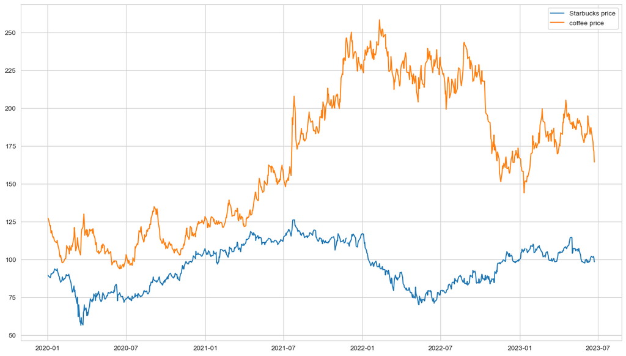

```python
plt.plot(test['date'], test['sbux_close'])
plt.plot(test['date'], test['coffee_close'])
plt.legend(['Starbucks price', 'coffee price'])
```

```python
test['sbux_ret'] = np.log(test['sbux_close']).diff()
test['coffee_ret'] = np.log(test['coffee_close']).diff()

test[['sbux_ret', 'coffee_ret']].corr()
```

|  | sbux_ret | coffee_ret |
| --- | --- | --- |
| sbux_ret | 1.000000 | 0.102518 |
| coffee_ret | 0.102518 | 1.000000 |

Zostawmy tą analizę na inny projekt

### Analiza log-zwrotów cen kawy

```python
coffee_prices = coffee['close']
coffee_returns = np.log(coffee['close']).diff()[1:]
```

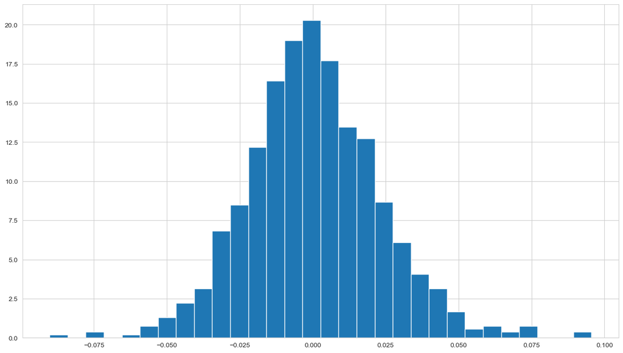

```python
coffee_returns.hist(density=True, bins='sqrt')
```

Załóżmy, że jest to rozkład normalny. A nawet sprawdźmy czy jest normalny

```python
coffee_returns_norm = (coffee_returns - np.mean(coffee_returns)) / np.std(coffee_returns)
[stat, pval] = sc.stats.kstest(coffee_returns_norm, sc.stats.norm.cdf)
print(f'KS test p-value: {pval}')
[stat, pval] = sc.stats.shapiro(coffee_returns_norm)
print(f'Shapiro p-value: {pval}')
```

```
KS test p-value: 0.2299583332712768
Shapiro p-value: 1.0727068911364768e-05
```

```python
mu = np.mean(coffee_returns)
std = np.std(coffee_returns)
print(f'dziennie zroty: N({mu}, {std}')

N_days = 252
mu_a = N_days * mu
std_a = np.sqrt(N_days) * std
print(f'roczne zwroty: N({mu_a}, {std_a}')

print('zmiennosc roczna zwykle jest ok. 20-40%, więc wyglada całkiem dobrze')
```

```
dziennie zroty: N(0.00029340658796514116, 0.022888317892469593
roczne zwroty: N(0.07393846016721557, 0.3633407824323873
zmiennosc roczna zwykle jest ok. 20-40%, więc wyglada całkiem dobrze
```

### Narzędzia do analizy

#### Ceny opcji - Black-Scholes

```python
N = norm.cdf

def BS_call(S, K, T, r, sigma):
    d1 = (np.log(S/K) + (r + sigma**2/2)*T) / (sigma*np.sqrt(T))
    d2 = d1 - sigma * np.sqrt(T)
    return S * N(d1) - K * np.exp(-r*T)* N(d2)

def BS_put(S, K, T, r, sigma):
    d1 = (np.log(S/K) + (r + sigma**2/2)*T) / (sigma*np.sqrt(T))
    d2 = d1 - sigma* np.sqrt(T)
    return K*np.exp(-r*T)*N(-d2) - S*N(-d1)

def Futures(S, T, r):
    return S*np.exp(r*T)
```

```python
r = 0.00
mu = r
S0 = coffee.iloc[-1]['close']

t = 0
T = 0.5 # 6 miesiecy

call_atm = BS_call(S0, S0, T, r, std_a)
put_atm = BS_put(S0, S0, T, r, std_a)

print(f'Obecna cena: {S0}')
print(f'cena opcji kupna ATM (czyli K=S_0): {call_atm}')
print(f'cena opcji sprzedaży ATM: {put_atm}')
print('Wygląda ok')
```

```
Obecna cena: 164.35000610351562
cena opcji kupna ATM (czyli K=S_0): 16.799091425821658
cena opcji sprzedaży ATM: 16.799091425821643
Wygląda ok
```

```python
# Sprawdzenie czy ceny wygląda rozsądnie
K_vec = np.linspace(0.7*S0, 1.3*S0, 100)
call_vec = [BS_call(S0, K, T, r, std_a) for K in K_vec]
put_vec = [BS_put(S0, K, T, r, std_a) for K in K_vec]
```

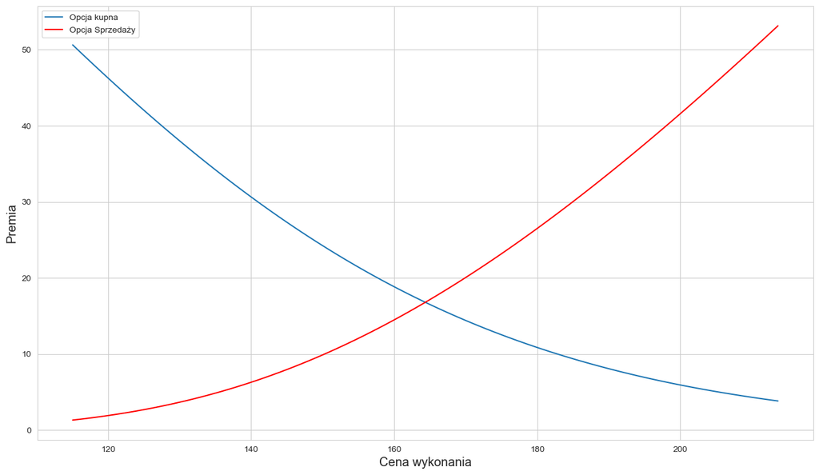

```python
plt.plot(K_vec, call_vec)
plt.plot(K_vec, put_vec, 'r')
plt.ylabel('Premia')
plt.xlabel('Cena wykonania')
plt.legend(['Opcja kupna', 'Opcja Sprzedaży'])
```

#### Symulacje Monte Carlo

```python
def MonteCarlo_sim(S0, T, mu, sigma, n, N):
    # calc each time step
    dt = T/n
    # simulation using numpy arrays
    St = np.exp(
        (mu - sigma ** 2 / 2) * dt
        + sigma * np.random.normal(0, np.sqrt(dt), size=(N,n)).T
    )
    # include array of 1's
    St = np.vstack([np.ones(N), St])
    # multiply through by S0 and return the cumulative product of elements along a given simulation path (axis=0).
    St = S0 * St.cumprod(axis=0)
    return St
```

```python
liczba_podzialow = 100
liczba_symulacji = 20
St = MonteCarlo_sim(S0, T, r, std_a, liczba_podzialow, liczba_symulacji)
```

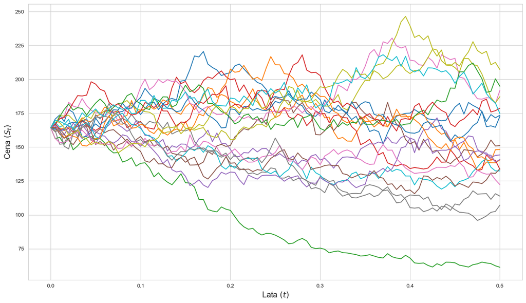

```python
# Define time interval correctly
time = np.linspace(0,T,liczba_podzialow+1)
# Require numpy array that is the same shape as St
tt = np.full(shape=(liczba_symulacji,liczba_podzialow+1), fill_value=time).T
# tt = time
plt.plot(time, St)
plt.xlabel("Lata $(t)$")
plt.ylabel("Cena $(S_t)$")
# plt.title(
#     "Realizacje GBM "\n $dS_t = \mu S_t dt + \sigma S_t dW_t$\n $S_0 = {0}, \mu = {1}, \sigma = {2}$".format(S0, mu, std_a)
# )
```

```
Srednia wartosc po 6 miesiacach: 164.4942203378193
```

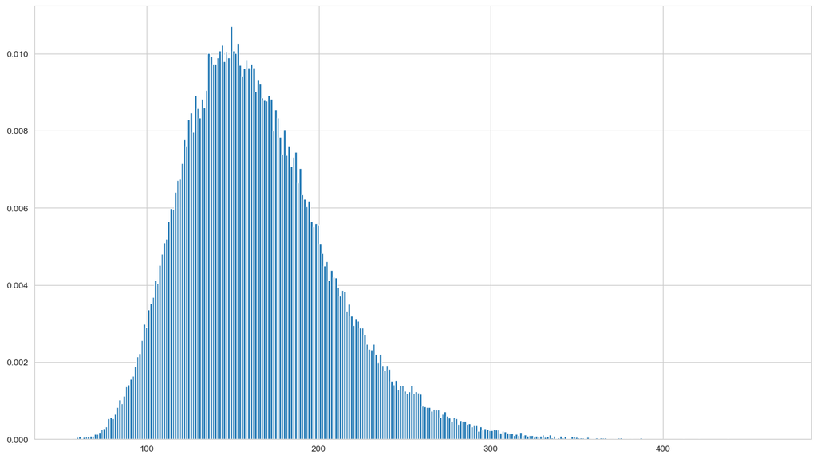

```python
# spradzmy czy rozklad cen w momencie T jest log-normalny

liczba_podzialow = 1
liczba_symulacji = 100000
St = MonteCarlo_sim(S0, T, r, std_a, liczba_podzialow, liczba_symulacji)

ostatnia_obserwacja = St[-1]
print(f'Srednia wartosc po 6 miesiacach: {np.mean(ostatnia_obserwacja)}')

plt.hist(ostatnia_obserwacja, bins='sqrt', density=True)
plt.show()
```

#### Sprawdzenie czy wycena opcji metodą Monte-Carlo = wycena metodą Black-Scholesa

```python
liczba_podzialow = 1
liczba_symulacji = 100000
St = MonteCarlo_sim(S0, T, r, std_a, liczba_podzialow, liczba_symulacji)

ostatnia_obserwacja = St[-1]

K = 100 # mozna wziac dowolna cene > 0

call_wyplata = [max(x - K, 0) for x in ostatnia_obserwacja]
put_wyplata = [max(K - x, 0) for x in ostatnia_obserwacja]

call_MC_premia = np.exp(-r*T) * np.mean(call_wyplata)
put_MC_premia = np.exp(-r*T) * np.mean(put_wyplata)

call_BS_premia = BS_call(S0, K, T, r, std_a)
put_BS_premia = BS_put(S0, K, T, r, std_a)

print(f'Premia za opcje kupna MC: {call_MC_premia}')
print(f'Premia za opcje kupna BS: {call_BS_premia}')
print(f'Premia za opcje sprzedazy MC: {put_MC_premia}')
print(f'Premia za opcje sprzedazy BS: {put_BS_premia}')
```

```
Premia za opcje kupna MC: 64.7296337725218
Premia za opcje kupna BS: 64.68122427023799
Premia za opcje sprzedazy MC: 0.32001467325651456
Premia za opcje sprzedazy BS: 0.3312181667223526
```

### Zarządzanie ryzykiem - 3 firmy

Rozpatrzmy 3 scenariusze

Starbucks

Wzrost cen ziaren kawy = większy koszty ponoszone przez firmę na jej zakup

**Cel**: Zabezpieczenie przed wzrostem cen kawy

Plantator (firma abc)

Spadek cen ziaren kawy = mniejsze zyski ze sprzedaży towaru

**Cel**: Zabezpieczenie przed spadkiem cen kawy

Plantator 2 (firma xyz) - **niewłaściwy sposób zabezpieczenia przed ryzykiem**

Spadek cen ziaren kawy = mniejsze zyski ze sprzedaży towaru

**Cel**: Zabezpieczenie przed spadkiem cen kawy... wraz z spekulacją

Spróbujemy odtworzyć zachowanie firm, które spowodowało kryzys finansowy w 2008 roku w Polsce

https://pl.wikipedia.org/wiki/Kryzys_opcji_walutowych_w_Polsce https://www.ue.katowice.pl/fileadmin/_migrated/content_uploads/18_B.Puszer_Opcje_Walutowe_w_Strategii....pdf

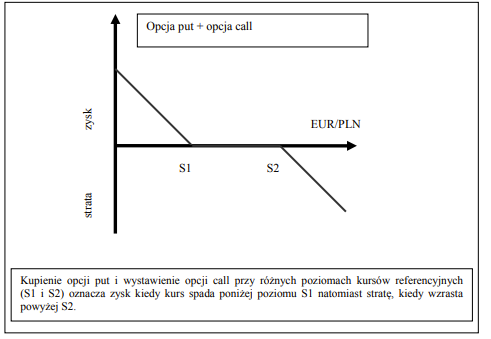

### Scenariusz 1 - Starbucks

Podmiot chce się zabezpieczyć przed wzrostem cen kawy w ciągu 6 miesięcy.

### brak strategii / zabezpieczeń - podjęcie ryzyka

```python
r = 0.00
S0 = coffee.iloc[-1]['close']
print(f'Obecna cena: {S0}')

t = 0
T = 0.5 # 6 miesiecy
```

```
Obecna cena: 164.35000610351562
```

```python
# price_at_moment_T = np.linspace(S0*0.7, S0*1.3)

# plt.plot(price_at_moment_T, S0-price_at_moment_T)
# plt.plot(price_at_moment_T, price_at_moment_T*0, 'r')
# plt.ylabel('Zysk')
# plt.xlabel('S(T) - Cena w momencie T')
# plt.legend(['Brak strategii', 'Odnośnik'])
```

Zamiast linspace moglibyśmy jednak użyć naszego MC dla lepszego obrazu możliwych cen w momencie T

```python
liczba_podzialow = 1
liczba_symulacji = 100000
St = MonteCarlo_sim(S0, T, r, std_a, liczba_podzialow, liczba_symulacji)
ostatnia_obserwacja = St[-1]

price_at_moment_T = np.array(sorted(ostatnia_obserwacja))
```

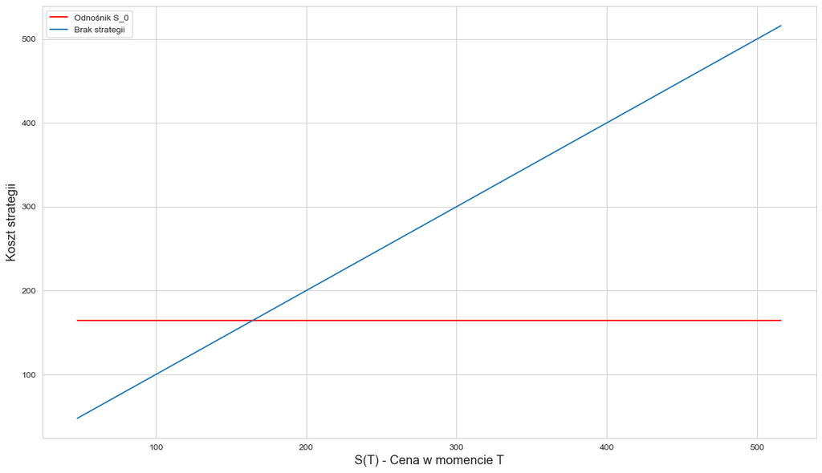

```python
plt.plot(price_at_moment_T, S0 + price_at_moment_T*0, 'r')
plt.plot(price_at_moment_T, price_at_moment_T)

plt.ylabel('Koszt strategii')
plt.xlabel('S(T) - Cena w momencie T')
plt.legend(['Odnośnik S_0', 'Brak strategii'])
```

Ewentualnie możemy patrzeć na zysk / stratę

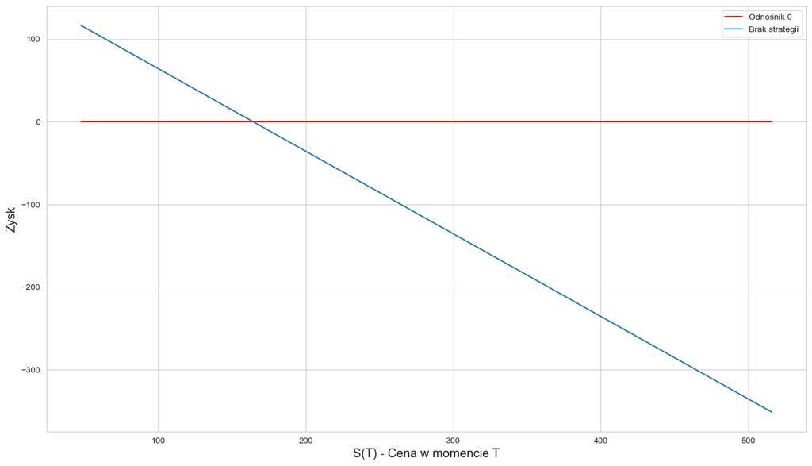

```python
plt.plot(price_at_moment_T, np.zeros(len(price_at_moment_T)), 'r')
plt.plot(price_at_moment_T, S0-price_at_moment_T)

plt.ylabel('Zysk')
plt.xlabel('S(T) - Cena w momencie T')
plt.legend(['Odnośnik 0', 'Brak strategii'])
```

### zabezpieczenie konktraktem futures/forward

(LF - long futures)

Zakup kontraktu forward na instrument podstawowy z terminem wykonania 6 miesięcy.

Czyli niezależnie od ceny za 6 miesięcy, KUPIMY towar po cenie F

```python
# hedging kontraktrem futures
F = Futures(S0, r, T)
print(f'Cena wykonania kontaktu wynosi: {F}')

futures_vec = F * np.ones(len(price_at_moment_T))
```

```
Cena wykonania kontaktu wynosi: 164.35000610351562
```

### zabezpieczenie opcją

(LC - Long Call)

```python
# hedging opcja kupna
K = S0

call_atm = BS_call(S0, S0, T, r, std_a)
print(f'opcja kupna: {call_atm}')

# Nasz całkowity koszt to premia opcji + cena, po której KUPIMY kawę za 6 miesięcy,
# czyli premia + minimum z ceny rynkowej i ceny wykonania opcji

option_vec = call_atm + [min(x, K) for x in price_at_moment_T]
```

```
opcja kupna: 16.799091425821658
```

### Podsumowanie

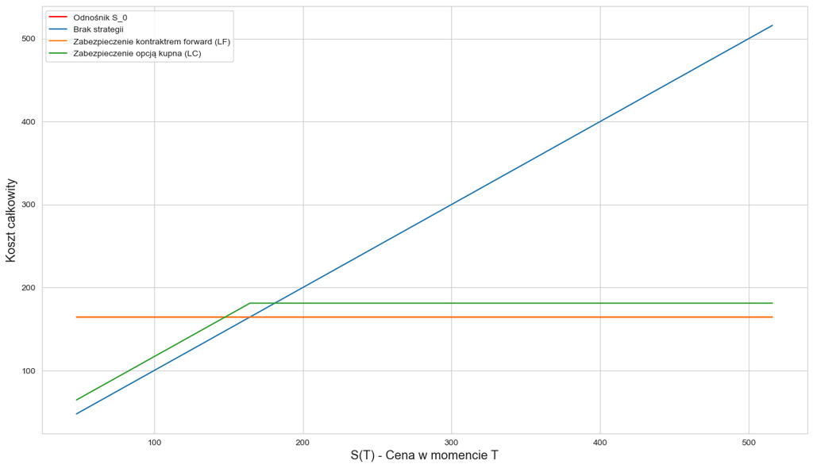

```python
# z tego należy zrobić tabelkę...

plt.plot(price_at_moment_T, S0 + price_at_moment_T*0, 'r')
plt.plot(price_at_moment_T, price_at_moment_T)
plt.plot(price_at_moment_T, futures_vec)
plt.plot(price_at_moment_T, option_vec)

plt.ylabel('Koszt całkowity')
plt.xlabel('S(T) - Cena w momencie T')
plt.legend(['Odnośnik S_0', 'Brak strategii', 'Zabezpieczenie kontraktrem forward (LF)', 'Zabezpieczenie opcją kupna (LC)'])
```

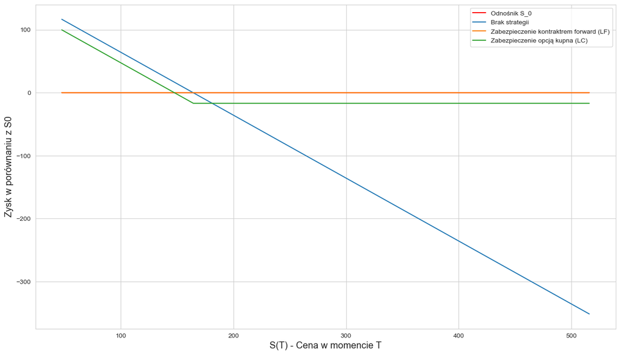

```python
plt.plot(price_at_moment_T, np.zeros(len(price_at_moment_T)), 'r')
plt.plot(price_at_moment_T, S0-price_at_moment_T)
plt.plot(price_at_moment_T, S0-futures_vec)
plt.plot(price_at_moment_T, S0-option_vec)

plt.ylabel('Zysk w porównaniu z S0')
plt.xlabel('S(T) - Cena w momencie T')
plt.legend(['Odnośnik S_0', 'Brak strategii', 'Zabezpieczenie kontraktrem forward (LF)', 'Zabezpieczenie opcją kupna (LC)'])
```

**Wnioski:**

- hedging opcją kupna At-The-Money nie jest najlepszym wyborem jeżeli ostatecznie cena jest blisko S0, wówczas strategie 1 i 2 wydają się bardziej korzystne
- w przypadku dużego spadku ceny, w strategii 3 nadal możemy kupić po cenie rynkowej (tracimy tylko zapłaconą premię) czyli lepiej niż futures
- w przypadku dużego wzrostu cen, w strategii 3 kupujemy po ustaloncej cenie (tracimy tylko zapłaconą premię), więc lepiej niż w przypadku braku strategii

```python
# VaR całkowitego kosztu

var_p_1 = round(np.quantile(price_at_moment_T, 0.95), 2)
var_p_2 = round(np.quantile(futures_vec, 0.95), 2)
var_p_3 = round(np.quantile(option_vec, 0.95), 2)

print(f'VaR całkowitego kosztu 95% - brak strategii: {var_p_1}')
print(f'VaR całkowitego kosztu 95% - zabezpieczenie futures: {var_p_2}')
print(f'VaR całkowitego kosztu 95% - zabezpieczenie opcją: {var_p_3}')
```

```
VaR całkowitego kosztu 95% - brak strategii: 242.48
VaR całkowitego kosztu 95% - zabezpieczenie futures: 164.35
VaR całkowitego kosztu 95% - zabezpieczenie opcją: 181.15
```

```python
# VaR strat w porównaniu z obecną ceną

var_p_1 = round(np.quantile(price_at_moment_T-S0, 0.95), 2)
var_p_2 = round(np.quantile(futures_vec-S0, 0.95), 2)
var_p_3 = round(np.quantile(option_vec-S0, 0.95), 2)

print(f'VaR dla strat względem S0 95% - brak strategii: {var_p_1}')
print(f'VaR dla strat względem S0 95% - zabezpieczenie futures: {var_p_2}')
print(f'VaR dla strat względem S0 95% - zabezpieczenie opcją: {var_p_3}')

var_p_1 = round(np.quantile(price_at_moment_T-S0, 0.99), 2)
var_p_2 = round(np.quantile(futures_vec-S0, 0.99), 2)
var_p_3 = round(np.quantile(option_vec-S0, 0.99), 2)

print('---------------------')
print(f'VaR dla strat względem S0 99% - brak strategii: {var_p_1}')
print(f'VaR dla strat względem S0 99% - zabezpieczenie futures: {var_p_2}')
print(f'VaR dla strat względem S0 99% - zabezpieczenie opcją: {var_p_3}')
```

```
VaR dla strat względem S0 95% - brak strategii: 78.13
VaR dla strat względem S0 95% - zabezpieczenie futures: 0.0
VaR dla strat względem S0 95% - zabezpieczenie opcją: 16.8
---------------------
VaR dla strat względem S0 99% - brak strategii: 123.9
VaR dla strat względem S0 99% - zabezpieczenie futures: 0.0
VaR dla strat względem S0 99% - zabezpieczenie opcją: 16.8
```

### Scenariusz 2 - plantator

Podmiot chce się zabezpieczyć przed spadkiem cen kawy w ciągu 6 miesięcy

### brak strategii / zabezpieczeń - podjęcie ryzyka

```python
r = 0.00
S0 = coffee.iloc[-1]['close']
print(f'Obecna cena: {S0}')

t = 0
T = 0.5 # 6 miesiecy
```

```
Obecna cena: 164.35000610351562
```

```python
# price_at_moment_T = np.linspace(S0*0.7, S0*1.3)

# plt.plot(price_at_moment_T, S0-price_at_moment_T)
# plt.plot(price_at_moment_T, price_at_moment_T*0, 'r')
# plt.ylabel('Zysk')
# plt.xlabel('S(T) - Cena w momencie T')
# plt.legend(['Brak strategii', 'Odnośnik'])
```

Moglibyśmy jednak użyć naszego MC dla lepszego obrazu możliwych cen w momencie T

```python
liczba_podzialow = 1
liczba_symulacji = 100000
St = MonteCarlo_sim(S0, T, r, std_a, liczba_podzialow, liczba_symulacji)
ostatnia_obserwacja = St[-1]

price_at_moment_T = np.array(sorted(ostatnia_obserwacja))
```

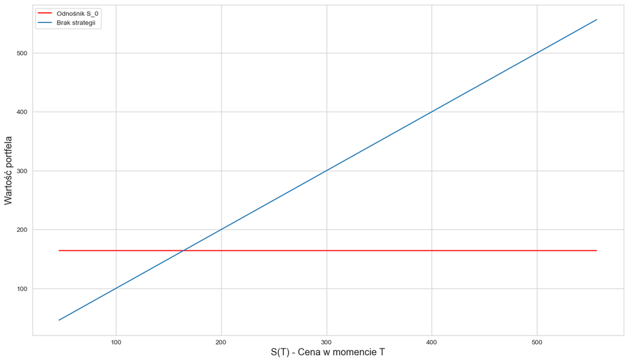

```python
plt.plot(price_at_moment_T, S0*np.ones(len(price_at_moment_T)), 'r')
plt.plot(price_at_moment_T, price_at_moment_T)

plt.ylabel('Wartość portfela')
plt.xlabel('S(T) - Cena w momencie T')
plt.legend(['Odnośnik S_0', 'Brak strategii'])
```

Ewentualnie możemy patrzeć na zysk / stratę

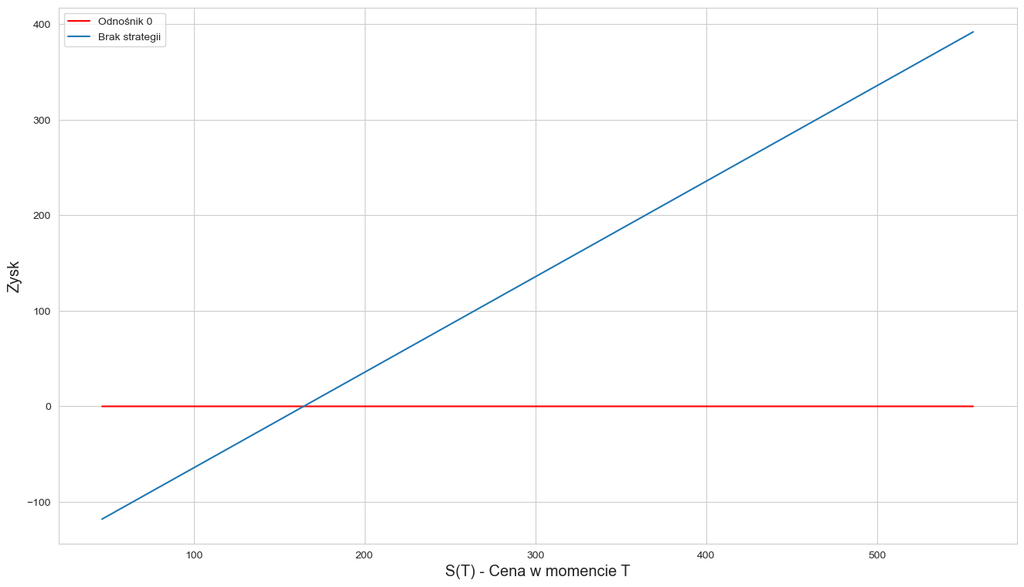

```python
plt.plot(price_at_moment_T, np.zeros(len(price_at_moment_T)), 'r')
plt.plot(price_at_moment_T, price_at_moment_T-S0)

plt.ylabel('Zysk')
plt.xlabel('S(T) - Cena w momencie T')
plt.legend(['Odnośnik 0', 'Brak strategii'])
```

### zabezpieczenie konktraktem futures/forward

(SF) Sprzedaż kontraktu forward na instrument podstawowy z terminem wykonania 6 miesięcy

Czyli niezależnie od ceny za 6 miesięcy, sprzedamy towar po cenie F

```python
# hedging kontraktrem futures
F = Futures(S0, r, T)
print(f'Cena wykonania kontaktu wynosi: {F}')

futures_vec = F * np.ones(len(price_at_moment_T))
```

```
Cena wykonania kontaktu wynosi: 164.35000610351562
```

### zabezpieczenie opcją

(LP - Long Put)

```python
# hedging opcja kupna
K = S0

put_atm = BS_put(S0, S0, T, r, std_a)
print(f'opcja sprzedaży: {put_atm}')

# -----------------------
# INACZEJ NIŻ W PRZYPADKU KUPUJĄCEGO)
# -----------------------
# Nasza wartość portfela to cena, po której SPRZEDAMY kawę za 6 miesięcy - cena opcji
# czyli (maximum z ceny rynkowej i ceny wykonania opcji) - premia za opcję

option_vec = - put_atm + [max(x, K) for x in price_at_moment_T]
```

```
opcja sprzedaży: 16.799091425821643
```

### Podsumowanie

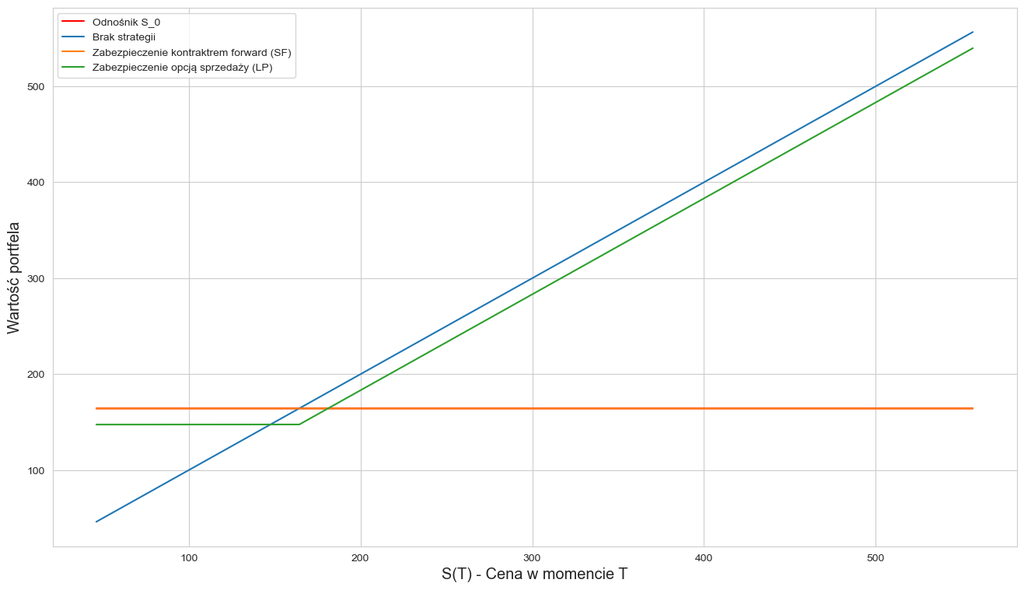

```python
plt.plot(price_at_moment_T, S0*np.ones(len(price_at_moment_T)), 'r')
plt.plot(price_at_moment_T, price_at_moment_T)
plt.plot(price_at_moment_T, futures_vec)
plt.plot(price_at_moment_T, option_vec)

plt.ylabel('Wartość portfela')
plt.xlabel('S(T) - Cena w momencie T')
plt.legend(['Odnośnik S_0', 'Brak strategii', 'Zabezpieczenie kontraktrem forward (SF)', 'Zabezpieczenie opcją sprzedaży (LP)'])
```

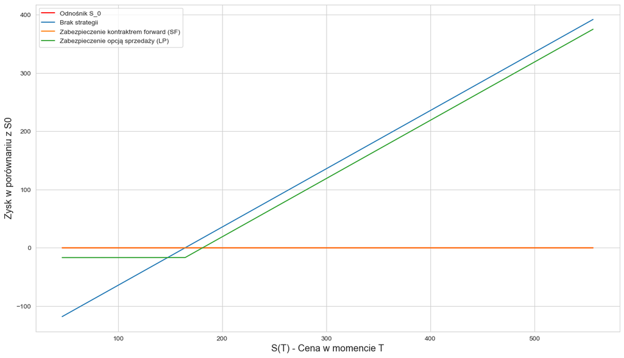

```python
plt.plot(price_at_moment_T, np.zeros(len(price_at_moment_T)), 'r')
plt.plot(price_at_moment_T, price_at_moment_T-S0)
plt.plot(price_at_moment_T, futures_vec-S0)
plt.plot(price_at_moment_T, option_vec-S0)

plt.ylabel('Zysk w porównaniu z S0')
plt.xlabel('S(T) - Cena w momencie T')
plt.legend(['Odnośnik S_0', 'Brak strategii', 'Zabezpieczenie kontraktrem forward (SF)', 'Zabezpieczenie opcją sprzedaży (LP)'])
```

```python
# VaR wartości portfela

var_p_1 = round(np.quantile(price_at_moment_T, 0.05), 2)
var_p_2 = round(np.quantile(futures_vec, 0.05), 2)
var_p_3 = round(np.quantile(option_vec, 0.05), 2)

print(f'VaR wartości portfela 95% - brak strategii: {var_p_1}')
print(f'VaR wartości portfela 95% - zabezpieczenie futures: {var_p_2}')
print(f'VaR wartości portfela 95% - zabezpieczenie opcją: {var_p_3}')
```

```
VaR wartości portfela 95% - brak strategii: 104.14
VaR wartości portfela 95% - zabezpieczenie futures: 164.35
VaR wartości portfela 95% - zabezpieczenie opcją: 147.55
```

```python
# VaR strat portfela

var_p_1 = round(np.quantile(S0-price_at_moment_T, 0.95), 2)
var_p_2 = round(np.quantile(S0-futures_vec, 0.95), 2)
var_p_3 = round(np.quantile(S0-option_vec, 0.95), 2)

print(f'VaR dla strat portfela względem S0 95% - brak strategii: {var_p_1}')
print(f'VaR dla strat portfela względem S0 95% - zabezpieczenie futures: {var_p_2}')
print(f'VaR dla strat portfela względem S0 95% - zabezpieczenie opcją: {var_p_3}')

var_p_1 = round(np.quantile(S0-price_at_moment_T, 0.99), 2)
var_p_2 = round(np.quantile(S0-futures_vec, 0.99), 2)
var_p_3 = round(np.quantile(S0-option_vec, 0.99), 2)

print('---------------------')
print(f'VaR dla strat portfela względem S0 99% - brak strategii: {var_p_1}')
print(f'VaR dla strat portfela względem S0 99% - zabezpieczenie futures: {var_p_2}')
print(f'VaR dla strat portfela względem S0 99% - zabezpieczenie opcją: {var_p_3}')
```

```
VaR dla strat portfela względem S0 95% - brak strategii: 60.21
VaR dla strat portfela względem S0 95% - zabezpieczenie futures: 0.0
VaR dla strat portfela względem S0 95% - zabezpieczenie opcją: 16.8
---------------------
VaR dla strat portfela względem S0 99% - brak strategii: 77.11
VaR dla strat portfela względem S0 99% - zabezpieczenie futures: 0.0
VaR dla strat portfela względem S0 99% - zabezpieczenie opcją: 16.8
```

```python
# ewentualnie VaR zwrotów portfela - sprawdźmy czy się zgadza

var_p_1 = round(np.quantile(price_at_moment_T - S0, 0.05), 2)
var_p_2 = round(np.quantile(futures_vec - S0, 0.05), 2)
var_p_3 = round(np.quantile(option_vec - S0, 0.05), 2)

print(f'VaR dla zwrotów portfela względem S0 95% - brak strategii: {var_p_1}')
print(f'VaR dla zwrotów portfela względem S0 95% - zabezpieczenie futures: {var_p_2}')
print(f'VaR dla zwrotów portfela względem S0 95% - zabezpieczenie opcją: {var_p_3}')

var_p_1 = round(np.quantile(price_at_moment_T - S0, 0.01), 2)
var_p_2 = round(np.quantile(futures_vec - S0, 0.01), 2)
var_p_3 = round(np.quantile(option_vec - S0, 0.01), 2)

print('---------------------')
print(f'VaR dla zwrotów portfela względem S0 99% - brak strategii: {var_p_1}')
print(f'VaR dla zwrotów portfela względem S0 99% - zabezpieczenie futures: {var_p_2}')
print(f'VaR dla zwrotów portfela względem S0 99% - zabezpieczenie opcją: {var_p_3}')
```

```
VaR dla zwrotów portfela względem S0 95% - brak strategii: -60.21
VaR dla zwrotów portfela względem S0 95% - zabezpieczenie futures: 0.0
VaR dla zwrotów portfela względem S0 95% - zabezpieczenie opcją: -16.8
---------------------
VaR dla zwrotów portfela względem S0 99% - brak strategii: -77.11
VaR dla zwrotów portfela względem S0 99% - zabezpieczenie futures: 0.0
VaR dla zwrotów portfela względem S0 99% - zabezpieczenie opcją: -16.8
```